# Naïve Bayes (NB) with Labeled Record Data

1. Overview of Naive Bayes Classification:
- Naive Bayes is a probabilistic classification technique based on Bayes’ Theorem with the assumption of independence between predictors (hence “naive”). In simple terms, it predicts the likelihood of an event based on prior knowledge of conditions related to that event.

2. Probabilistic Nature and Bayes’ Theorem Foundation:

- Naive Bayes operates on the principle of probability. It calculates the probability of an event in the presence of a particular feature using Bayes’ theorem. Bayes’ theorem finds the probability of an event occurring, given the probability of another related event.
- The fundamental equation behind this method is: P(A|B) = [P(B|A) * P(A)] / P(B), where:
- P(A|B) is the probability of hypothesis A given data B.
- P(B|A) is the probability of data B given hypothesis A.
- P(A) and P(B) are the probabilities of observing hypothesis A and data B independently of each other.

3. Objectives of Using Naive Bayes:

- The primary objective when using the Naive Bayes classification is to predict the class of the given dataset and to understand the probability that a given data point belongs to a particular category or class.

4. Aims of Naive Bayes Classification:

- With Naive Bayes, the aim is to assign an observation to a class such that the posterior probability is maximized. In other words, it tries to find the class label for a given data point by maximizing the posterior probability.

5. Variants of Naive Bayes:

- There are mainly three types of Naive Bayes models:
- Gaussian: It assumes that continuous features follow a normal distribution. It’s used when the data has continuous attributes.
- Multinomial: Suitable for discrete data. It’s commonly used in text classification problems.
- Bernoulli: Used for binary/boolean features.

6. When to Use Each Variant:

- Gaussian is generally used for datasets with continuous data points.
- Multinomial is used for datasets with discrete data points (e.g., word counts for text classification).
- Bernoulli is useful when feature vectors are binary (e.g., whether a word occurs in a document or not).

```r
# data <- read.csv("../.././data./01-modified-data./cleaned_data_r2.csv", stringsAsFactors = FALSE)
data <- read.csv("../../data/01-modified-data/cleaned_data_r2.csv", stringsAsFactors = FALSE)


filter_data <- data[, c("Year", "Runtime", "Rating", "Genres", "Director", "Writers", "Cast")]


filter_data$Genres <- sub("\\|.*", "", filter_data$Genres)
filter_data$Cast <- sub("\\|.*", "", filter_data$Cast)


filter_data <- filter_data[filter_data$Runtime != 0, ]
str(filter_data)
```

```
'data.frame':   3747 obs. of  7 variables:
 $ Year    : int  2017 2005 2001 2017 2000 2018 2007 2017 2011 2018 ...
 $ Runtime : int  66 75 65 99 79 95 91 91 107 108 ...
 $ Rating  : num  7.4 7.9 6.8 7.6 6.4 6.6 7.2 8.1 7.4 6.4 ...
 $ Genres  : chr  "Uncategorized" "Documentary" "Adventure" "Drama" ...
 $ Director: chr  "Bobcat Goldthwait" "Greg Whiteley" "Tony Craig" "Vincent Grashaw" ...
 $ Writers : chr  "Patton Oswalt" "Arthur Kane" "Thomas Hart" "Brett Haley" ...
 $ Cast    : chr  "Patton Oswalt" "Sylvain Sylvain" "Carlos Alazraqui" "Arman Darbo" ...
```

```r
library(caret)
set.seed(42)

initialSplit <- createDataPartition(filter_data$Rating, p = 0.8, list = FALSE)
trainValid_data <- filter_data[initialSplit, ]
test_data <- filter_data[-initialSplit, ]

trainIndex <- createDataPartition(trainValid_data$Rating, p = 0.75, list = FALSE)
train_data <- trainValid_data[trainIndex, ]
valid_data <- trainValid_data[-trainIndex, ]
```

**Explain how and why is it necessary to split a dataset into training and test sets.**

Datasets are often split into training and test sets for machine learning and statistical modeling needs. Here are the reasons why:

Avoiding Overfitting: By testing the model on separate datasets, we can avoid overfitting the model to the training data (also known as overfitting). If the model performs well on the training set but not on the test set, this usually means that the model is overfitting.

Evaluating Performance: The test set provides us with a tool to evaluate the performance of the model on new, unseen data. This provides us with an objective measure of the model’s ability to generalize.

Model Selection: By comparing the performance of different models or parameter settings on the test set, we can select the best model or parameter combination.

```r
library(e1071)
library(caret)

model_NB <- naiveBayes(Rating ~ ., data=train_data)
```

```r
predictions <- predict(model_NB, test_data)

all_levels <- unique(c(levels(predictions), levels(test_data$Rating)))

predictions <- factor(predictions, levels = all_levels)
test_data$Rating <- factor(test_data$Rating, levels = all_levels)

cm <- confusionMatrix(predictions, test_data$Rating)
print(cm)
```

```
Confusion Matrix and Statistics

          Reference
Prediction 1.7 2.3 2.4 2.5 2.7 2.8 2.9 3.1 3.2 3.3 3.4 3.5 3.6 3.7 3.8 3.9 4
       1.7   0   0   0   0   0   0   0   0   0   0   0   0   0   0   0   0 0
       2.3   0   0   0   0   0   0   0   0   0   0   0   0   0   0   0   0 0
       2.4   0   0   0   0   0   0   0   0   0   0   0   0   0   0   0   0 0
       2.5   0   0   0   0   0   0   0   0   0   0   0   0   0   0   0   0 0
       2.7   0   0   0   0   0   0   0   0   0   0   0   0   0   0   0   0 0
       2.8   0   0   0   0   0   0   0   0   0   0   0   0   0   0   0   0 0
       2.9   0   0   0   0   0   0   0   0   0   0   0   0   0   0   0   0 0
       3.1   0   0   0   0   0   0   0   0   0   0   0   0   0   0   0   0 0
       3.2   0   0   0   0   0   0   0   0   0   0   0   0   0   0   0   0 0
       3.3   0   0   0   0   0   0   0   0   0   0   0   0   0   0   0   0 0
       3.4   0   0   0   0   0   0   0   0   0   0   0   0   0   0   0   0 0
       3.5   0   0   0   0   0   0   0   0   0   0   0   0   0   0   0   0 0
       3.6   0   0   0   0   1   0   0   0   1   0   0   1   0   0   0   0 1
       3.7   0   0   0   0   0   0   0   0   0   0   0   0   0   0   0   0 0
       3.8   0   0   0   0   0   0   0   0   0   0   0   0   0   0   0   0 0
       3.9   0   0   0   0   0   0   0   0   0   0   0   0   0   0   0   0 0
       4     0   0   0   0   0   0   0   0   0   0   0   0   0   0   0   0 0
       4.1   0   0   0   0   0   0   0   0   0   0   0   0   0   0   0   0 0
       4.2   0   0   0   0   0   0   0   0   0   0   0   0   0   0   0   0 0
       4.3   0   0   0   0   0   0   0   0   0   0   0   0   0   0   0   0 0
       4.4   0   0   0   0   0   0   0   0   0   0   0   0   0   0   0   0 0
       4.5   0   0   0   0   0   0   0   0   0   0   0   0   0   0   0   0 0
       4.6   0   0   0   0   0   0   0   0   0   0   0   0   0   0   0   0 0
       4.7   0   0   0   0   0   0   0   0   0   0   0   0   0   0   0   0 0
       4.8   0   0   0   0   0   0   0   0   0   0   0   0   0   0   0   0 0
       4.9   0   0   0   0   0   0   0   0   0   0   0   0   0   0   0   0 0
       5     0   0   0   1   0   0   0   0   0   0   0   0   1   0   0   0 0
       5.1   0   0   0   0   0   0   0   0   0   0   0   0   0   0   0   0 0
       5.2   0   0   0   0   0   0   0   0   0   0   0   0   0   0   0   0 0
       5.3   0   0   0   0   0   0   0   0   0   0   0   0   0   0   0   0 0
       5.4   0   0   0   0   0   0   0   0   0   0   1   0   0   0   0   0 1
       5.5   0   0   0   0   0   0   0   0   0   0   0   0   0   0   0   0 0
       5.6   0   0   0   0   0   0   0   0   0   0   0   0   0   0   0   0 0
       5.7   0   0   0   0   0   0   0   0   0   0   0   0   0   0   0   0 0
       5.8   0   0   0   0   0   0   0   0   0   0   0   0   0   0   0   0 0
       5.9   0   0   0   0   0   0   0   0   0   0   0   0   0   0   0   0 0
```

[output cut: 367 more lines]

```
Pos Pred Value         0.000000    0.00000        NaN         NA         NA
Neg Pred Value         0.997315    0.99866    0.99866         NA         NA
Prevalence             0.002681    0.00134    0.00134          0    0.00000
Detection Rate         0.000000    0.00000    0.00000          0    0.00000
Detection Prevalence   0.001340    0.00134    0.00000          0    0.00134
Balanced Accuracy      0.499328    0.49933    0.50000         NA         NA
                     Class: 8.9 Class: 9 Class: 9.5
Sensitivity                  NA       NA         NA
Specificity                   1        1          1
Pos Pred Value               NA       NA         NA
Neg Pred Value               NA       NA         NA
Prevalence                    0        0          0
Detection Rate                0        0          0
Detection Prevalence          0        0          0
Balanced Accuracy            NA       NA         NA
```

```r
accuracy <- cm$overall['Accuracy']
precision <- cm$byClass['Precision']
recall <- cm$byClass['Recall']
F1 <- 2 * (precision * recall) / (precision + recall)
accuracy
```

```
  Accuracy
0.04691689
```

```r
precision
```

```
[1] NA
```

```r
recall
```

```
[1] NA
```

```r
F1
```

```
[1] NA
```

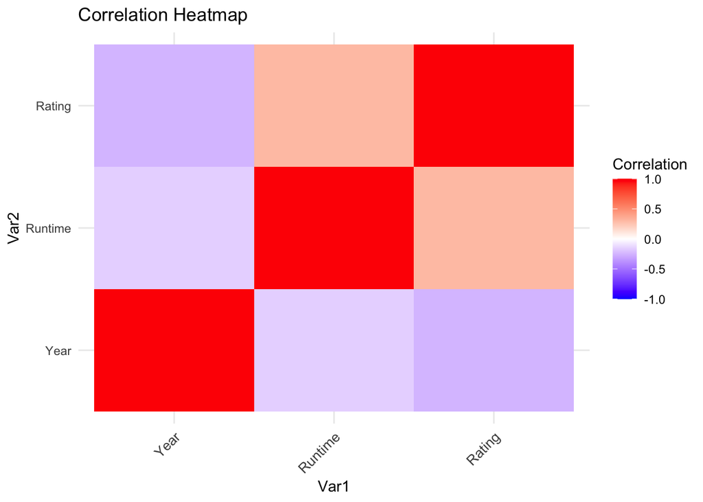

```r
library(ggplot2)
library(reshape2)

numeric_data <- filter_data[, sapply(filter_data, is.numeric)]
cor_matrix <- cor(numeric_data, use = "complete.obs")

melted_cormat <- melt(cor_matrix)
ggplot(data = melted_cormat, aes(x=Var1, y=Var2, fill=value)) +
  geom_tile() +
  scale_fill_gradient2(low="blue", high="red", mid="white",
                       midpoint=0, limit=c(-1,1), space="Lab",
                       name="Correlation") +
  theme_minimal() +
  labs(title = "Correlation Heatmap") +
  theme(axis.text.x = element_text(angle = 45, vjust = 1,
                                    size = 10, hjust = 1))
```

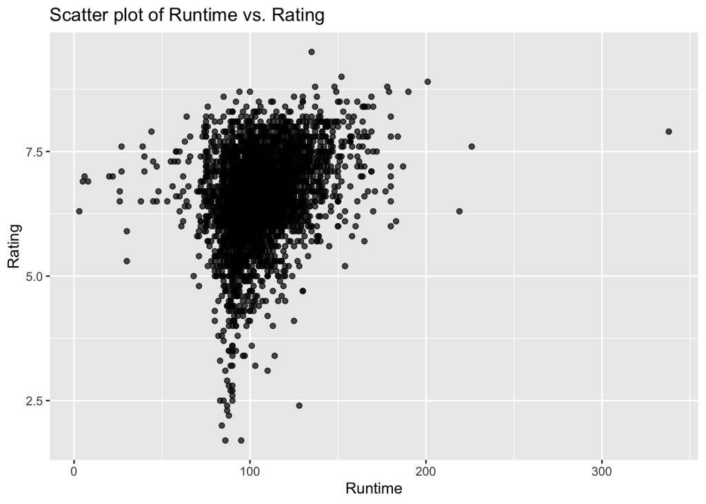

```r
ggplot(filter_data, aes(x=Runtime, y=Rating)) +
  geom_point(alpha=0.7) +
  labs(title="Scatter plot of Runtime vs. Rating", x="Runtime", y="Rating")
```

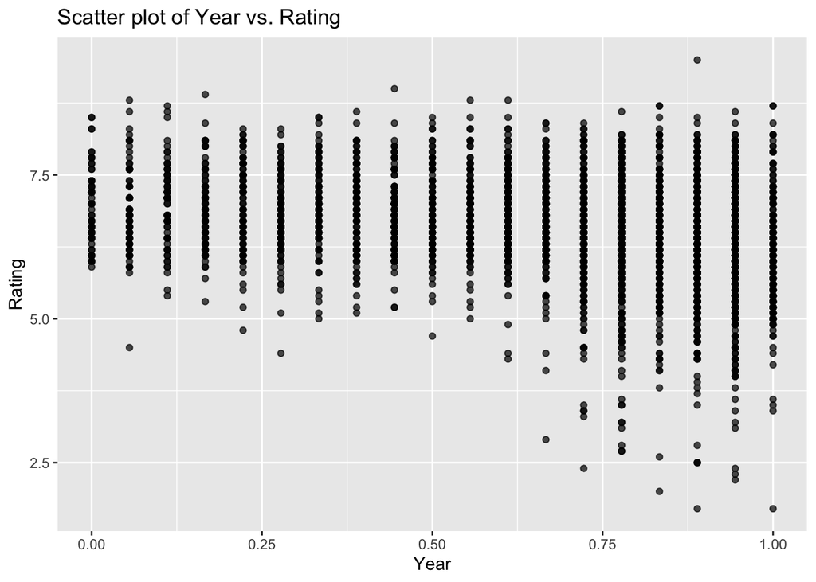

```r
filter_data$Year <- (filter_data$Year - min(filter_data$Year)) / (max(filter_data$Year) - min(filter_data$Year))

ggplot(filter_data, aes(x=Year, y=Rating)) +
  geom_point(alpha=0.7) +
  labs(title="Scatter plot of Year vs. Rating", x="Year", y="Rating")
```

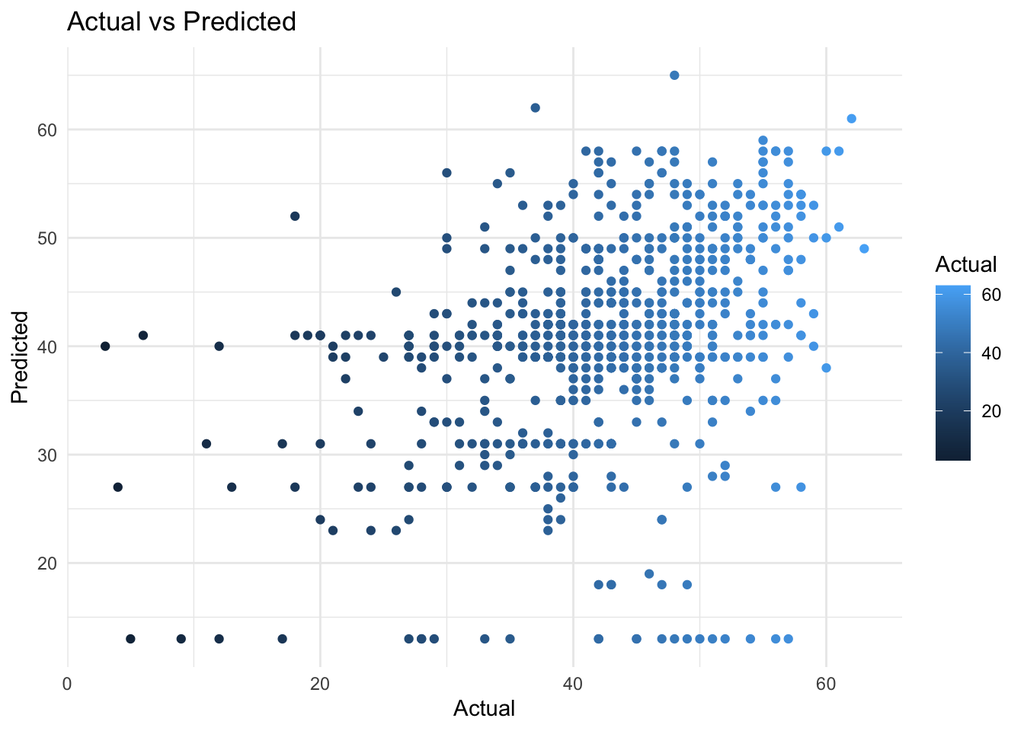

```r
library(ggplot2)

comparison <- as.data.frame(cbind(Actual=test_data$Rating, Predicted=predictions))
ggplot(comparison, aes(x=Actual, y=Predicted)) + geom_point(aes(color=Actual)) +
  ggtitle('Actual vs Predicted') + theme_minimal()
```

**Discuss the concepts of overfitting and under-fitting and whether your model is doing it.**

I’ve added as many relevant features as I can, and the model has close to 4,000 records, but the accuracy is very low, suggesting that the correlation between these features is very low. I will try to find more relevant datasets to repeat this question in subsequent assignments.

**Discuss the model’s performance in terms of accuracy and other relevant metrics.**

The accuracy is too low causing several other metrics of my model to show NA, I will try to find a more compliant dataset in subsequent assignments